# Turn up the Heat! A Tutorial for the MAGMA R-package.

Julian Urban, Markus D. Feuchter, Vsevolod Scherrer, Moritz L. Breit, and Franzis Preckel

# Summary

# Introduction

Lack of experimental control is an issue in field research, observational, and non-randomized studies. A popular method to control for the effects of covariates post-hoc is propensity score matching (PSM; Rosenbaum & Rubin, 1983, 1985). By balancing out the effects of covariates, PSM approxiamtes causal inference. Since causal inference is fundamental in science, PSM is used in many scientific fields such as in organizational (e.g., Li, 2013), educational (e.g., Powell et al., 2020), and social science (e.g., Thoemmes & Kim, 2011) as well as in medical research (e.g., Austin, 2014).

PSM builds statistical pairs of individuals, for example from a treatment group and a control group, based on the distance on a specific variable. Propensity scores are often used in representation of said distance (for a review, see Stuart, 2010). They express the conditional probability of belonging to a group (e.g., the treatment group) given a set of covariates (Rosenbaum & Rubin, 1985). Although a plethora of matching techniques exist, a commonly applied method is nearest neighbor matching (Austin, 2014; Jacovidis, 2017). By matching a treated individual to its non-treated nearest neighbor, PSM controls for the effects of covariates.

PSM’s potential is nonetheless limited due to three reasons. First, current techniques are restricted to binary treatment variables, and hence, to two-group designs (for first approaches, see Imai & van Dyk, 2004; McCaffrey et al., 2013). Second, researchers must successively extract and compare several arbitrary matching solutions by hand, instead of having access to a comprehensive, unambiguous overview of possible matching solutions. Third, there is no comprehensive framework for evaluating the quality of matching solutions, especially when multiple groups are involved. We addressed these issues with our MAGMA package. For an extensive overview of MAGMA and its balance framework, see Feuchter at al. (2022).

The aims of this vignette are to provide a tutorial for the MAGMA R-package. This includes examples for all currently available group scenarios, namely two, three, and four groups, as well as 2x2 designs. We conducted these examples for standard and exact matching. Moreover, this tutorial contains examples on how to report matching relevant statistics. Lastly, we demonstrate how to compute and report balance of individual PSM solutions, using our newly developed framework.

# The MAGMA Simulated Dataset

We used a simulated data set for all examples. This simulated dataset contains 800 cases and 14 variables. It is available after installing the MAGMA package. Associations between the variables were modeled to increase the usability and comprehensibility of this tutorial, and are, therefore, not representative of specific real-life phenomena. For information about this simulated dataset, use `?MAGMA_sim_data`. Below is a brief look at the data and its structure. Note that the last three variables are propensity scores that were estimated using the `twang` package (Ridgeway et al., 2015). For a detailed overview and tutorial on `twang`, see (Ridgeway et al., 2015). Propensity scores estimated via twang serve as distance indicators for all subsequent examples.

For the two group example, we use the propensity score `ps_gifted`. This score expresses the conditional probability of receiving `gifted_support`. It was computed using the `ps` function of `twang`. The propensity scores `ps_tar` (three group example) and `ps_2x2` (four group / 2x2 design example) are the result of the `mnps` function of `twang`. They express the conditional probability for the groups `teacher_rated_ability` (below average, average, above average) and the combination of receiving `gifted_support` and participating in afternoon `enrichment` respectively.

```r
str(MAGMA_sim_data)
```

```
#> 'data.frame':    800 obs. of  14 variables:
#>  $ ID                    : int  1 2 3 4 5 6 7 8 9 10 ...
#>  $ gender                : int  1 0 1 1 1 0 0 0 1 0 ...
#>  $ gifted_support        : int  1 1 1 1 1 1 0 1 0 1 ...
#>  $ teacher_ability_rating: int  3 2 2 1 3 3 2 2 1 1 ...
#>  $ enrichment            : int  0 1 0 1 0 0 0 0 0 1 ...
#>  $ parents_academic      : int  1 1 1 0 1 0 0 1 0 0 ...
#>  $ GPA_school            : num  4.73 4.41 3.23 2.88 2.98 ...
#>  $ IQ_score              : num  111.6 97.8 120.1 97.9 74.4 ...
#>  $ Motivation            : num  5.36 4.41 3.57 4.34 3.54 ...
#>  $ college_GPA           : num  4.01 3.41 2.73 4.02 4.09 ...
#>  $ support_enrichment    : int  3 4 3 4 3 3 1 3 1 4 ...
#>  $ ps_tar                : num  0.0657 0.1085 0.1899 0.4261 0.4782 ...
#>  $ ps_2x2                : num  0.3 0.32 0.21 0.237 0.571 ...
#>  $ ps_gifted             : num  0.431 0.364 0.626 0.353 0.187 ...
```

# Two-Group Example

This is a fictitious two-group example. The independent variable (i.e., the treatment) is `gifted_support`. We are interested in how receiving giftedness support affects college GPA. However, other variables, such as intelligence, previous achievement, and motivation are associated with both giftedness support and college GPA. This is because gifted students were chosen to participate in this support program based on their previous achievement or intelligence test results. Therefore, we aim to reduce differences on these covariates between the two groups by PSM. For this example, the covariates are *high school GPA*, *intelligence*, *motivation*, *gender*, and whether at least one parent has an *academic background*. Note that MAGMA can only consider metric and binary variables for balance estimation.

```r
covariates_gifted <- c("GPA_school",
                       "IQ_score",
                       "Motivation",
                       "parents_academic",
                       "gender")
```

Defining all covariates beforehand (see above)nfacilitates estimations of descriptive statistics, standardized mean differences, and hence, the initial unbalance across all cases of our dataset. To do this we can use the functions `MAGMA_desc` and `initial_unbalance`. The first function – `MAGMA_desc` – computes sample size, mean, and standard deviation of all covariates for the overall sample and the two groups. Moreover, it estimates the standardized mean differences using the pooled standard deviation (i.e., Cohen’s *d*) between the two groups. This function needs the dataset (`MAGMA_sim_data`), the grouping variable (`gifted_support`), and all binary and metric covariates of interest (`covariates_gifted`). The function results in a table that contains these statistics for each covariate.

The second function – `initial_unbalance` - estimates the four balance criteria of our balance framework. These criteria are (1) *Pillai’s Trace*, which estimates group differences across all variables, (2) *d-ratio*, which expresses the percentage of how many pairwise effects are negligible, (3) *mean g*, which specifies the average pariwise effect using meta-analytical techniques, and (4) *adjusted d-ratio*, an adjusted version of (2) that respects that effects are point estimates. For more information, see Feuchter et al. (2022). The function `initial_unbalance` indicates the unbalance in the sample before matching. To this end, it is necessary to define the dataset (`MAGMA_sim_data`), the grouping variable (`gifted_support`), and all binary and metric covariates of interest (`covariates_gifted`). This results in a vector of length four - the four balance criteria.

```r
# Estimate overall and group specific descriptive statistics and Cohen’s d
descs_gifted_pre <- MAGMA_desc(Data = MAGMA_sim_data,
                               group = "gifted_support",
                               covariates = covariates_gifted,
                               filename = "stats_gifted_pre.docx")
descs_gifted_pre %>%
  purrr::set_names(c("Overall N", "Overall Mean", "Overall SD",
                     "No Support N", "No Support Mean", "No Support SD",
                     "Support N", "Support Mean", "Support SD",
                     "d"))
```

```
#>                  Overall N Overall Mean Overall SD No Support N No Support Mean
#> gifted_support         800         0.38       0.49          495            0.00
#> GPA_school             800         3.29       0.93          495            3.13
#> IQ_score               800       100.51      15.00          495           96.32
#> Motivation             800         3.82       0.89          495            3.81
#> parents_academic       800         0.40       0.49          495            0.35
#> gender                 800         0.50       0.50          495            0.50
#>                  No Support SD Support N Support Mean Support SD     d
#> gifted_support            0.00       305         1.00       0.00  -Inf
#> GPA_school                0.91       305         3.56       0.89 -0.48
#> IQ_score                 14.20       305       107.30      13.75 -0.78
#> Motivation                0.90       305         3.83       0.88 -0.02
#> parents_academic          0.48       305         0.48       0.50 -0.27
#> gender                    0.50       305         0.49       0.50  0.02
```

```r
# Estimating the four balance criteria
unbalance_gifted <- initial_unbalance(Data = MAGMA_sim_data,
                                      group = "gifted_support",
                                      covariates = covariates_gifted)
```

```
#> [1] "Mean g was computed using random effects meta-analysis with metafor."
```

```r
unbalance_gifted
```

```
#>           Pillai's Trace d-ratio Mean g adj. d-ratio
#> Unbalance           0.13     0.4   0.31          0.4
```

As may be expected from the descriptive statistics, the cases that received giftedness support differed substantially from the cases that did not receive giftedness support on at least some covariates. Before we start matching, we check the possibility of eligible matches. Therefore, we estimate and plot the common support in propensity score via the kernel-density (Pastore et al., 2022) and the function `density_overlap`. This function requires the dataset (`MAGMA_sim_data`), the variable for which the overlap should be computed (`ps_gifted`), and the grouping variable (`gifted_support`). The remaining arguments of the functions define aesthetics of the plot, namely the name of the variable (`variable_name`), the name of the group (`group_name`), and the labels of the respective groups (`group_labels`). The function returns a density plot and a value expressing the overlapping area.

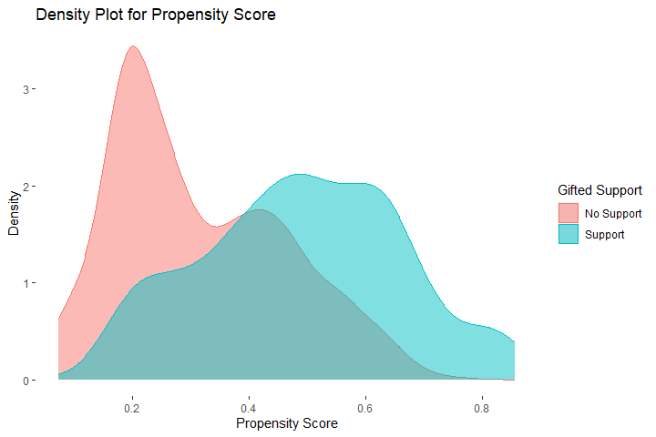

```
#>        OV
#> 0.6162573
```

```r
# Density overlap in propensity scores for gifted before matching
Density_overlap(Data = MAGMA_sim_data,
                variable = "ps_gifted",
                group = "gifted_support",
                variable_name = "Propensity Score",
                group_labels = c("No Support", "Support"),
                group_name = "Gifted Support")
```

As we can see, there is substantial common support between the two groups. After these initial checks, we can conduct the matching. This process is based on the respective propensity score, `ps_gifted`. We first address standard matching before introducing a case of exact matching.